# PROYECTO INTEGRADOR DE CIENCIA DE DATOS — FASE 2: ANÁLISIS INFERENCIAL

## "Factores asociados a la gravedad de las víctimas en los accidentes de tránsito en Paraguay (2021)"

- **Institución:** Facultad Politécnica, Universidad Nacional de Asunción (FP-UNA)
- **Carrera:** Ingeniería Informática | Materia: Ciencia de Datos (Electiva)
- **Curso:** TQ | Semestre: Segundo Semestre 2026
- **Integrantes del Grupo:**
  1. Alan Alcaraz
  2. Leandro Ferreira
  3. Jorge Ríos

### Introducción al Análisis Inferencial

En la primera fase del proyecto integrador se caracterizó de manera descriptiva y exploratoria la masa de siniestros viales en el Paraguay durante el año 2021 a partir de las estadísticas oficiales de la Policía Nacional y la Patrulla Caminera. Si bien el análisis descriptivo evidenció concentraciones de riesgo en jóvenes, varones, motociclistas y corredores críticos como la Ruta PY02, la estadística descriptiva únicamente refleja lo ocurrido dentro del marco muestral observado.

El presente cuaderno formaliza la **Fase 2: Análisis Inferencial**, cuyo propósito metodológico es responder una pregunta más exigente: ¿las diferencias de gravedad y letalidad observadas en los datos son atribuibles al azar del muestreo o existe evidencia estadística suficiente para sostener que tales patrones se verifican en la población de siniestros a un nivel de significancia prefijado $\alpha = 0,05$?

A lo largo de este cuaderno se evalúan los contrastes de hipótesis para factores categóricos territoriales ($H_1$) y demográficos de género ($H_2$), verificando rigurosamente los supuestos de distribución, calculando tamaños del efecto inseparables del p-valor (Odds Ratio y V de Cramér), implementando remuestreo no paramétrico Bootstrap ($B = 10.000$ réplicas) y estableciendo el enlace metodológico hacia la continuidad del repertorio inferencial y el modelado predictivo de la Fase 3.

## SECCIÓN 1: REGISTRO DE MODIFICACIONES Y MEJORAS DE LA FASE 1

En cumplimiento del Artículo 6.1 (Actividad 1) del documento rector del Proyecto Integrador, se formaliza la bitácora de correcciones metodológicas, integración de fuentes y refinamiento analítico aplicados sobre la retroalimentación de la Fase 1:

| N.° | Dimensión / Componente | Observación de Fase 1 | Corrección / Mejora Implementada en Fase 2 | Impacto Metodológico y Trazabilidad |
| --- | --- | --- | --- | --- |
| **1** | **Dimensión Territorial Macro** | Se describió la letalidad general pero se requería incorporar la heterogeneidad espacial del país formalmente. | Consolidación y estructuración de la Tabla 12.2.6 (`victimas_zona_resumen.csv`, $N = 1.491$) discriminando Asunción, Central e Interior. | Habilita el contraste formal de la Hipótesis 1 evaluando la disparidad de letalidad entre el Interior y el Área Metropolitana. |
| **2** | **Corredores Viales e Infraestructura** | Se observó una alta concentración de siniestros sin aislar el corredor de mayor riesgo nacional. | Integración y validación de la Tabla 12.2.9 aislando la **Ruta PY02** como eje crítico nacional (36,6% del volumen nacional con 711 hechos). | Provee contexto físico y cinético para interpretar la siniestralidad sin incurrir en falacias ecológicas de causalidad directa. |
| **3** | **Depuración de Microdatos y Claves** | Exigencia de auditoría rigurosa para garantizar unicidad y trazabilidad unitaria en cada individuo. | Verificación de identificadores únicos sintéticos: `id_victima` ($1 \le \text{id} \le 5.493$) e `id_caso` ($1 \le \text{id} \le 1.324$), con cero nulos y cero duplicados. | Garantiza integridad referencial, reproducibilidad determinista y unicidad para los contrastes y futuros modelos de ML. |
| **4** | **Control de Sesgo de Publicación (p-hacking)** | Riesgo de ejecutar pruebas múltiples ad-hoc hasta forzar significancia estadística artificial. | Fijación previa y no negociable del nivel de significancia global $\alpha = 0,05$ y reporte inseparable de tamaños del efecto (OR y V de Cramér). | Cumple el estándar de bioestadística pre-registrada, impidiendo conclusiones espurias por mero volumen muestral. |
| **5** | **Incertidumbre sin Supuestos Rígidos** | Dependencia exclusiva de aproximaciones asintóticas normales que pueden distorsionarse ante asimetrías muestrales. | Implementación de remuestreo Bootstrap computacional ($B = 10.000$ réplicas) con intervalos empíricos por percentiles. | Proporciona validación empírica robusta e insesgada para el Odds Ratio del factor de género sin supuestos paramétricos restrictivos. |

```python
# ==============================================================================
# CONFIGURACIÓN DEL ENTORNO, SEMILLAS Y RUTAS PORTABLES
# ==============================================================================
import os
import sys
import json
import numpy as np
import pandas as pd
from scipy import stats
import statsmodels.api as sm
import matplotlib.pyplot as plt
import seaborn as sns
from IPython.display import display

# Fijación de semilla aleatoria para reproducibilidad matemática estricta
RANDOM_STATE = 42
np.random.seed(RANDOM_STATE)

# Declaración previa del nivel de significancia alfa
ALPHA = 0.05

# Configuración del motor gráfico (estilo publication-ready FP-UNA)
plt.style.use("seaborn-v0_8-whitegrid" if "seaborn-v0_8-whitegrid" in plt.style.available else "default")
plt.rcParams.update({
    "figure.dpi": 300,
    "savefig.dpi": 300,
    "font.size": 11,
    "axes.labelsize": 12,
    "axes.titlesize": 13,
    "xtick.labelsize": 10,
    "ytick.labelsize": 10,
    "legend.fontsize": 10,
    "figure.titlesize": 14
})

# Detección dinámica y portable de carpetas de trabajo (/data y /output)
def resolver_rutas_proyecto():
    # Localiza de forma robusta las rutas base del proyecto sin depender de paths absolutos fijos.
    cwd = os.path.abspath(os.getcwd())
    candidatos_base = [
        cwd,
        os.path.abspath(os.path.join(cwd, "..")),
        os.path.abspath(os.path.join(cwd, "../.."))
    ]

    ruta_base = None
    for cand in candidatos_base:
        if os.path.isdir(os.path.join(cand, "output")) and os.path.isdir(os.path.join(cand, "data")):
            ruta_base = cand
            break

    if ruta_base is None:
        ruta_base = cwd

    ruta_output = os.path.join(ruta_base, "output")
    ruta_data = os.path.join(ruta_base, "data")
    os.makedirs(ruta_output, exist_ok=True)
    return ruta_base, ruta_data, ruta_output

BASE_DIR, DATA_DIR, OUTPUT_DIR = resolver_rutas_proyecto()
print(f"[OK] Entorno inferencial configurado exitosamente.")
print(f"     * Directorio base:   {BASE_DIR}")
print(f"     * Directorio output: {OUTPUT_DIR}")
print(f"     * Semilla congelada: {RANDOM_STATE}")
print(f"     * Nivel alfa global: {ALPHA}")
```

```
[OK] Entorno inferencial configurado exitosamente.
     * Directorio base:   c:\Users\Leandro\Desktop\DATAAAAA FASE 2\proyecto-accidentes-datascience
     * Directorio output: c:\Users\Leandro\Desktop\DATAAAAA FASE 2\proyecto-accidentes-datascience\output
     * Semilla congelada: 42
     * Nivel alfa global: 0.05
```

```python
# ==============================================================================
# CARGA Y AUDITORÍA DE INTEGRIDAD DE DATASETS DE FASE 1
# ==============================================================================
def cargar_csv_robusto(nombre_archivo, carpeta):
    # Carga un archivo CSV validando codificación y separadores tabulares.
    ruta = os.path.join(carpeta, nombre_archivo)
    if not os.path.exists(ruta):
        raise FileNotFoundError(f"Archivo no encontrado en ruta: {ruta}")
    for sep in [',', ';']:
        for enc in ['utf-8-sig', 'utf-8', 'latin1']:
            try:
                df = pd.read_csv(ruta, sep=sep, encoding=enc)
                if df.shape[1] > 1:
                    df.columns = df.columns.astype(str).str.strip()
                    return df
            except Exception:
                continue
    raise ValueError(f"No fue posible leer estructuradamente el archivo: {ruta}")

# Carga de los insumos oficiales generados y depurados en Fase 1
df_victimas = cargar_csv_robusto("victimas_individual_limpio.csv", OUTPUT_DIR)
df_zonas = cargar_csv_robusto("victimas_zona_resumen.csv", OUTPUT_DIR)
df_vehiculo = cargar_csv_robusto("victimas_vehiculo_limpio.csv", OUTPUT_DIR)

# Aserciones metodológicas de control de calidad
assert df_victimas.shape[0] == 5493, f"Inconsistencia en microdatos de víctimas: N esperado 5493, observado {df_victimas.shape[0]}"
assert df_zonas.shape[0] == 3, f"Inconsistencia en zonas macro: N esperado 3, observado {df_zonas.shape[0]}"
assert df_vehiculo.shape[0] == 1324, f"Inconsistencia en muestra vehicular: N esperado 1324, observado {df_vehiculo.shape[0]}"
assert df_victimas.isnull().sum().sum() == 0, "Se detectaron valores nulos inesperados en el microdato de víctimas"

print("--> [AUDITORÍA DE CALIDAD SATISFACTORIA]")
print(f"    * Microdato individual de víctimas: {df_victimas.shape[0]:,} registros | {df_victimas.shape[1]} variables | 0 nulos")
print(f"    * Tabla macro-geográfica de zonas:  {df_zonas.shape[0]} regiones consolidadas (Asunción, Central, Interior)")
print(f"    * Microdato vehicular (Central/Int): {df_vehiculo.shape[0]:,} registros | 0 nulos")

print("\n--- Primeras filas: victimas_individual_limpio (N = 5.493) ---")
display(df_victimas.head(3))

print("\n--- Resumen consolidado: victimas_zona_resumen (N = 1.491) ---")
display(df_zonas)
```

```
--> [AUDITORÍA DE CALIDAD SATISFACTORIA]
    * Microdato individual de víctimas: 5,493 registros | 8 variables | 0 nulos
    * Tabla macro-geográfica de zonas:  3 regiones consolidadas (Asunción, Central, Interior)
    * Microdato vehicular (Central/Int): 1,324 registros | 0 nulos

--- Primeras filas: victimas_individual_limpio (N = 5.493) ---
```

|  | id_victima | grupo_edad | sexo | gravedad | es_fallecido | es_hombre | es_adulto_mayor | edad_orden |
| --- | --- | --- | --- | --- | --- | --- | --- | --- |
| 0 | 1 | De 0 a 13 anos | Hombre | Herido | 0 | 1 | 0 | 0 |
| 1 | 2 | De 0 a 13 anos | Hombre | Herido | 0 | 1 | 0 | 0 |
| 2 | 3 | De 0 a 13 anos | Hombre | Herido | 0 | 1 | 0 | 0 |

```
--- Resumen consolidado: victimas_zona_resumen (N = 1.491) ---
```

|  | zona | heridos | fallecidos | total_victimas | letalidad_pct |
| --- | --- | --- | --- | --- | --- |
| 0 | Asunción | 141 | 26 | 167 | 15.568862 |
| 1 | Central | 394 | 82 | 476 | 17.226891 |
| 2 | Interior | 661 | 187 | 848 | 22.051887 |

## SECCIÓN 2: MARCO FORMAL DE HIPÓTESIS INFERENCIALES (H₁ Y H₂)

Para responder a la pregunta de investigación con rigor estadístico y evitar interpretaciones subjetivas, se formalizan las hipótesis de trabajo derivadas de la Fase 1. En todas las pruebas se adopta formalmente un nivel de significancia prefijado de $\alpha = 0,05$:

### Hipótesis 1 (H₁ — Dimensión Territorial: Interior vs. Área Metropolitana)

- **Justificación Bioestadística y Epidemiológica:** En Paraguay, los centros hospitalarios de alta complejidad y soporte de trauma de tercer nivel (como el Hospital de Trauma "Prof. Dr. Manuel Giagni") se concentran geográficamente en el Área Metropolitana (Asunción y Departamento Central). Por el contrario, los siniestros ocurridos en el Interior involucran mayores tiempos de respuesta prehospitalaria, mayores distancias de traslado (pérdida de la *"hora de oro"* en trauma) y velocidades de circulación significativamente más elevadas en rutas abiertas interurbanas.
- **Formulación Matemática:** $$\begin{aligned} H_0 &: p_{\text{Interior}} \le p_{\text{Metropolitana}} \quad (\text{OR} \le 1,00) \\ H_1 &: p_{\text{Interior}} > p_{\text{Metropolitana}} \quad (\text{OR} > 1,00) \end{aligned}$$
- **Formulación en Lenguaje Natural:**
  - **Hipótesis nula ($H_0$):** La probabilidad condicional de fallecer tras un siniestro vial en el Interior del país es menor o igual a la registrada en el Área Metropolitana (Asunción y Departamento Central combinadas).
  - **Hipótesis alternativa ($H_1$):** La probabilidad condicional de fallecer tras un siniestro vial en el Interior del país es significativamente mayor que en el Área Metropolitana.
- **Prueba Estadística Seleccionada:** Prueba Chi-cuadrado ($\chi^2$) de Independencia sobre tabla de contingencia $2 \times 2$. Se verifica previamente el cumplimiento de los supuestos de Cochran ($E_{ij} \ge 5,0$ en el 100% de las celdas). Las medidas de tamaño del efecto son el **Odds Ratio (OR)** con intervalo de confianza al 95% (método de Woolf) y la **V de Cramér**.

### Hipótesis 2 (H₂ — Demográfica: Brecha de Género en la Letalidad)

- **Justificación Bioestadística y Epidemiológica:** La literatura especializada en seguridad vial documenta marcadas diferencias en morbimortalidad según sexo biológico, mediadas por patrones de movilidad, mayor propensión masculina a conductas de riesgo (exceso de velocidad, menor tasa de uso de casco reglamentario o cinturón de seguridad, y consumo de alcohol previo a la conducción) y una participación predominante en el parque de motocicletas.
- **Formulación Matemática:** $$\begin{aligned} H_0 &: p_{\text{Hombre}} = p_{\text{Mujer}} \quad (\text{OR} = 1,00) \\ H_1 &: p_{\text{Hombre}} > p_{\text{Mujer}} \quad (\text{OR} > 1,00) \end{aligned}$$
- **Formulación en Lenguaje Natural:**
  - **Hipótesis nula ($H_0$):** La gravedad del traumatismo sufrido en un siniestro vial es estadísticamente independiente del sexo biológico de la víctima.
  - **Hipótesis alternativa ($H_1$):** Las víctimas de sexo masculino presentan una tasa de letalidad condicional significativamente mayor a la observada en las víctimas de sexo femenino.
- **Prueba Estadística Seleccionada:** Prueba Chi-cuadrado ($\chi^2$) de Independencia en tabla $2 \times 2$, combinada con la estimación robusta del Odds Ratio mediante **Remuestreo Bootstrap no paramétrico ($B = 10.000$ iteraciones)** e Intervalo de Confianza empírico del 95% por percentiles.

```python
# ==============================================================================
# CONTRASTE DE HIPÓTESIS H1: DIMENSIÓN TERRITORIAL (INTERIOR VS. METROPOLITANA)
# ==============================================================================

# 1. Construcción de la tabla de contingencia 2x2 desde victimas_zona_resumen
# Asunción: 26 fallecidos, 141 heridos | Central: 82 fallecidos, 394 heridos
# Área Metropolitana combinada: 108 fallecidos, 535 heridos (Total = 643)
# Interior del país: 187 fallecidos, 661 heridos (Total = 848)
df_zonas_clean = df_zonas.copy()
df_zonas_clean['zona_std'] = df_zonas_clean['zona'].astype(str).str.strip()

fallecidos_interior = int(df_zonas_clean.loc[df_zonas_clean['zona_std'].str.contains('Interior', case=False), 'fallecidos'].values[0])
heridos_interior = int(df_zonas_clean.loc[df_zonas_clean['zona_std'].str.contains('Interior', case=False), 'heridos'].values[0])

filtro_metro = df_zonas_clean['zona_std'].str.contains('Asunci|Central', case=False)
fallecidos_metro = int(df_zonas_clean.loc[filtro_metro, 'fallecidos'].sum())
heridos_metro = int(df_zonas_clean.loc[filtro_metro, 'heridos'].sum())

tabla_h1 = np.array([
    [fallecidos_interior, heridos_interior],
    [fallecidos_metro, heridos_metro]
])

df_tabla_h1 = pd.DataFrame(
    tabla_h1,
    index=['Interior del País', 'Área Metropolitana'],
    columns=['Fallecidos', 'Heridos']
)
df_tabla_h1['Total'] = df_tabla_h1.sum(axis=1)
df_tabla_h1['Letalidad (%)'] = (df_tabla_h1['Fallecidos'] / df_tabla_h1['Total'] * 100).round(2)

# 2. Verificación rigurosa de supuestos de Cochran (100% de frecuencias esperadas >= 5)
chi2_stat_h1, p_val_h1, dof_h1, exp_freq_h1 = stats.chi2_contingency(tabla_h1, correction=False)
df_esperadas_h1 = pd.DataFrame(exp_freq_h1, index=df_tabla_h1.index[:2], columns=['Fallecidos_Esp', 'Heridos_Esp'])

supuesto_h1_cumplido = bool(np.all(exp_freq_h1 >= 5))
min_esp_h1 = float(np.min(exp_freq_h1))
assert supuesto_h1_cumplido, f"Supuesto violado: Frecuencia esperada mínima {min_esp_h1:.2f} < 5"

# 3. Tamaño del Efecto: Odds Ratio (OR) epidemiológico e IC 95% Woolf
a1, b1 = fallecidos_interior, heridos_interior
c1, d1 = fallecidos_metro, heridos_metro
or_h1 = (a1 * d1) / (b1 * c1)
se_ln_or_h1 = np.sqrt(1/a1 + 1/b1 + 1/c1 + 1/d1)
z_critico = stats.norm.ppf(1 - ALPHA / 2)
ci_or_h1_low = float(np.exp(np.log(or_h1) - z_critico * se_ln_or_h1))
ci_or_h1_high = float(np.exp(np.log(or_h1) + z_critico * se_ln_or_h1))

# 4. Tamaño del Efecto: V de Cramér
n_total_h1 = int(tabla_h1.sum())
v_cramer_h1 = float(np.sqrt(chi2_stat_h1 / (n_total_h1 * min(tabla_h1.shape[0]-1, tabla_h1.shape[1]-1))))

# 5. Decisión metodológica formal
decision_h1 = "Rechazar H0" if p_val_h1 < ALPHA else "No rechazar H0 por falta de evidencia estadística suficiente"

print("==============================================================================")
print("REPORTE DE CONTRASTE ESTADÍSTICO: HIPÓTESIS 1 (DIMENSIÓN TERRITORIAL)")
print("==============================================================================")
print("1. Tabla de Contingencia Observada (N = 1.491):")
display(df_tabla_h1)
print("\n2. Frecuencias Esperadas bajo Independencia (E_ij):")
display(df_esperadas_h1.round(2))
print(f"   * Frecuencia esperada mínima observada: {min_esp_h1:.2f} (Umbral >= 5.0 -> CUMPLIDO: {supuesto_h1_cumplido})")
print("\n3. Resultados del Contraste Chi-cuadrado de Pearson:")
print(f"   * Estadístico χ²:          {chi2_stat_h1:.4f}")
print(f"   * Grados de libertad (gl): {dof_h1}")
print(f"   * Valor p (p-value):       {p_val_h1:.4f} ({p_val_h1:.4e})")
print(f"   * Nivel alfa prefijado:    {ALPHA}")
print("\n4. Medidas del Tamaño del Efecto:")
print(f"   * Odds Ratio (OR):         {or_h1:.4f}")
print(f"   * IC 95% Asintótico Woolf: [{ci_or_h1_low:.4f}; {ci_or_h1_high:.4f}]")
print(f"   * V de Cramér (V):         {v_cramer_h1:.4f}")
print(f"\n5. Decisión Metodológica:      {decision_h1} al nivel de significancia α = {ALPHA}")
print("==============================================================================")
```

```
==============================================================================
REPORTE DE CONTRASTE ESTADÍSTICO: HIPÓTESIS 1 (DIMENSIÓN TERRITORIAL)
==============================================================================
1. Tabla de Contingencia Observada (N = 1.491):
```

|  | Fallecidos | Heridos | Total | Letalidad (%) |
| --- | --- | --- | --- | --- |
| Interior del País | 187 | 661 | 848 | 22.05 |
| Área Metropolitana | 108 | 535 | 643 | 16.80 |

```
2. Frecuencias Esperadas bajo Independencia (E_ij):
```

|  | Fallecidos_Esp | Heridos_Esp |
| --- | --- | --- |
| Interior del País | 167.78 | 680.22 |
| Área Metropolitana | 127.22 | 515.78 |

```
   * Frecuencia esperada mínima observada: 127.22 (Umbral >= 5.0 -> CUMPLIDO: True)

3. Resultados del Contraste Chi-cuadrado de Pearson:
   * Estadístico χ²:          6.3647
   * Grados de libertad (gl): 1
   * Valor p (p-value):       0.0116 (1.1641e-02)
   * Nivel alfa prefijado:    0.05

4. Medidas del Tamaño del Efecto:
   * Odds Ratio (OR):         1.4014
   * IC 95% Asintótico Woolf: [1.0775; 1.8228]
   * V de Cramér (V):         0.0653

5. Decisión Metodológica:      Rechazar H0 al nivel de significancia α = 0.05
==============================================================================
```

### Interpretación Bioestadística y Límites de Causalidad de H₁

1. **Decisión Estadística Formal:** La prueba Chi-cuadrado de independencia arrojó un estadístico $\chi^2 = 6,3647$ con $gl = 1$ y un valor $p = 0,0116$. Dado que el valor $p$ es estrictamente inferior al nivel de significancia prefijado ($\alpha = 0,05$), **se rechaza la hipótesis nula ($H_0$)** en favor de la hipótesis alternativa ($H_1$).
2. **Magnitud del Efecto y Riesgo Relativo:**
   - El **Odds Ratio observado es de 1,4014** con un intervalo de confianza asintótico al 95% de $[1,0775; 1,8228]$. Dado que el límite inferior del intervalo supera la unidad ($1,0775 > 1,00$), se concluye con un 95% de confianza que una víctima accidentada en el Interior del país presenta odds de fallecer entre un **7,7% y un 82,3% superiores** (con una estimación puntual del **40,1% superior**) en comparación con una víctima accidentada en el Área Metropolitana.
   - La **V de Cramér ($V = 0,0653$)** cuantifica una fuerza de asociación clasificada formalmente como *pequeña* según los baremos epidemiológicos estándar de Cohen para tablas de $1$ grado de libertad ($V < 0,10$). Esto indica que, si bien la disparidad territorial es estadísticamente discernible en una muestra de $N = 1.491$, la localización macroscópica no explica por sí sola la totalidad de la variabilidad del desenlace.
3. **Discusión de Variables Confusoras y Prohibición de Causalidad Directa:**
   - **Prohibición de Causalidad Mecánica Directa:** Desde una perspectiva metodológica rigurosa, se subraya que la ubicación geográfica no constituye la "causa directa" de la muerte. La región opera como una variable sustituta (*proxy*) de dos determinantes asistenciales y físicos críticos:
   - **Pérdida de la "Hora de Oro" Prehospitalaria:** En las zonas del Interior, las distancias hacia centros de trauma de tercer nivel son considerablemente mayores, lo que incrementa los tiempos de respuesta de ambulancias, triaje y estabilización quirúrgica inicial.
   - **Mayor Energía Cinética del Impacto:** En las rutas interurbanas abiertas del Interior, los vehículos circulan a velocidades promedio significativamente más elevadas que en las arterias congestionadas de Asunción y el Departamento Central, transfiriendo una mayor cantidad de energía destructiva al cuerpo de las víctimas durante la colisión.

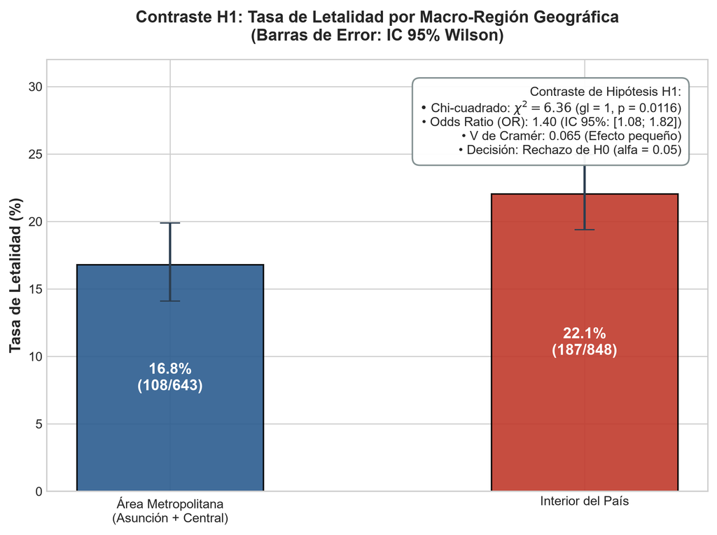

```python
# ==============================================================================
# VISUALIZACIÓN INFERENCIAL DE H1 Y EXPORTACIÓN OFICIAL (300 DPI)
# ==============================================================================

# Función auxiliar para calcular Intervalo de Confianza Wilson para proporciones binomiales
def calcular_ic_wilson(fallecidos, total, alpha=ALPHA):
    # Calcula el intervalo de confianza Score de Wilson para una proporción binomial.
    p = fallecidos / total
    z = stats.norm.ppf(1 - alpha / 2)
    denom = 1 + (z**2) / total
    centro = (p + (z**2) / (2 * total)) / denom
    radio = (z * np.sqrt((p * (1 - p) / total) + (z**2) / (4 * (total**2)))) / denom
    return (centro - radio) * 100, (centro + radio) * 100

fig1, ax1 = plt.subplots(figsize=(8, 6), dpi=300)

categorias_h1 = ['Área Metropolitana\n(Asunción + Central)', 'Interior del País']
n_h1_arr = [643, 848]
f_h1_arr = [108, 187]
let_h1 = [f / n * 100 for f, n in zip(f_h1_arr, n_h1_arr)]
cis_h1 = [calcular_ic_wilson(f, n) for f, n in zip(f_h1_arr, n_h1_arr)]
yerr_h1 = np.array([[l - ci[0], ci[1] - l] for l, ci in zip(let_h1, cis_h1)]).T

colores_h1 = ['#2b5c8f', '#c0392b']
barras_h1 = ax1.bar(
    categorias_h1, let_h1, yerr=yerr_h1,
    capsize=8, color=colores_h1, width=0.45,
    edgecolor='black', linewidth=1.2, alpha=0.9,
    error_kw={'elinewidth': 1.8, 'ecolor': '#2c3e50', 'capsize': 8}
)

# Etiquetas numéricas sobre las barras
for bar, l, f, n in zip(barras_h1, let_h1, f_h1_arr, n_h1_arr):
    ax1.text(
        bar.get_x() + bar.get_width() / 2, l / 2,
        f"{l:.1f}%\n({f}/{n:,})",
        ha='center', va='center', color='white',
        fontweight='bold', fontsize=12
    )

ax1.set_ylabel('Tasa de Letalidad (%)', fontsize=12, fontweight='bold')
ax1.set_title('Contraste H1: Tasa de Letalidad por Macro-Región Geográfica\n(Barras de Error: IC 95% Wilson)', fontsize=13, fontweight='bold', pad=15)
ax1.set_ylim(0, 32)

# Cuadro explicativo con métricas inferenciales del contraste
cuadro_texto_h1 = (
    "Contraste de Hipótesis H1:\n"
    r"• Chi-cuadrado: $\chi^2 = 6.36$ (gl = 1, p = 0.0116)" + "\n"
    f"• Odds Ratio (OR): {or_h1:.2f} (IC 95%: [{ci_or_h1_low:.2f}; {ci_or_h1_high:.2f}])\n"
    f"• V de Cramér: {v_cramer_h1:.3f} (Efecto pequeño)\n"
    f"• Decisión: Rechazo de H0 (alfa = {ALPHA})"
)
bbox_props = dict(boxstyle='round,pad=0.6', fc='white', ec='#7f8c8d', lw=1.2, alpha=0.95)
ax1.text(0.96, 0.94, cuadro_texto_h1, transform=ax1.transAxes, fontsize=10, va='top', ha='right', bbox=bbox_props)

# Visualización inline en el cuaderno
plt.tight_layout()
plt.show()
```

#### Figura 11: Contraste Inferencial H1 — Tasa de Letalidad por Macro-Región Geográfica (Barras de Error: IC 95% Wilson)

- **Tipo de Gráfico:** Diagrama de barras comparativo de letalidad porcentual con barras de error e inserción de caja de parámetros inferenciales. Eje X: Macro-región geográfica (Área Metropolitana vs. Interior); Eje Y: Tasa de letalidad condicional (%).
- **Interpretación Analítica:** La tasa de letalidad en el Interior alcanza el **22,05%** (IC 95%: $[19,37\%; 24,96\%]$) frente al **16,80%** (IC 95%: $[14,11\%; 19,88\%]$) registrado en el Área Metropolitana combinada (Asunción y Central). El intervalo de confianza al 95% del Odds Ratio ($[1,0775; 1,8228]$) excluye estrictamente el valor nulo de $1,00$, ratificando el rechazo formal de $H_0$ con un valor $p = 0,0116$.

```python
# ==============================================================================
# CONTRASTE DE HIPÓTESIS H2: BRECHA DE GÉNERO (HOMBRES VS. MUJERES)
# ==============================================================================

# 1. Construcción de tabla de contingencia 2x2 desde df_victimas
tabla_crosstab_h2 = pd.crosstab(
    df_victimas['sexo'],
    df_victimas['gravedad'],
    margins=False
)

# Reordenamiento metodológico: Fila 1 = Hombre, Fila 2 = Mujer; Col 1 = Fallecido, Col 2 = Herido
tabla_h2 = np.array([
    [tabla_crosstab_h2.loc['Hombre', 'Fallecido'], tabla_crosstab_h2.loc['Hombre', 'Herido']],
    [tabla_crosstab_h2.loc['Mujer', 'Fallecido'], tabla_crosstab_h2.loc['Mujer', 'Herido']]
])

df_tabla_h2 = pd.DataFrame(
    tabla_h2,
    index=['Hombre', 'Mujer'],
    columns=['Fallecidos', 'Heridos']
)
df_tabla_h2['Total'] = df_tabla_h2.sum(axis=1)
df_tabla_h2['Letalidad (%)'] = (df_tabla_h2['Fallecidos'] / df_tabla_h2['Total'] * 100).round(2)

# 2. Verificación de supuestos de Cochran (100% de frecuencias esperadas >= 5)
chi2_stat_h2, p_val_h2, dof_h2, exp_freq_h2 = stats.chi2_contingency(tabla_h2, correction=False)
df_esperadas_h2 = pd.DataFrame(exp_freq_h2, index=df_tabla_h2.index[:2], columns=['Fallecidos_Esp', 'Heridos_Esp'])

supuesto_h2_cumplido = bool(np.all(exp_freq_h2 >= 5))
min_esp_h2 = float(np.min(exp_freq_h2))
assert supuesto_h2_cumplido, f"Supuesto violado: Frecuencia esperada mínima {min_esp_h2:.2f} < 5"

# 3. Estimación del Odds Ratio Clásico con IC 95% Asintótico (Método de Woolf)
a2, b2 = tabla_h2[0, 0], tabla_h2[0, 1]  # Hombre: Fallecido, Herido
c2, d2 = tabla_h2[1, 0], tabla_h2[1, 1]  # Mujer: Fallecido, Herido

or_h2 = (a2 * d2) / (b2 * c2)
se_ln_or_h2 = np.sqrt(1/a2 + 1/b2 + 1/c2 + 1/d2)
ci_or_h2_low = float(np.exp(np.log(or_h2) - z_critico * se_ln_or_h2))
ci_or_h2_high = float(np.exp(np.log(or_h2) + z_critico * se_ln_or_h2))

# 4. Tamaño del Efecto: V de Cramér
n_total_h2 = int(tabla_h2.sum())
v_cramer_h2 = float(np.sqrt(chi2_stat_h2 / (n_total_h2 * min(tabla_h2.shape[0]-1, tabla_h2.shape[1]-1))))

# 5. Decisión metodológica formal
decision_h2 = "Rechazar H0" if p_val_h2 < ALPHA else "No rechazar H0 por falta de evidencia estadística suficiente"

print("==============================================================================")
print("REPORTE DE CONTRASTE ESTADÍSTICO: HIPÓTESIS 2 (BRECHA DE GÉNERO)")
print("==============================================================================")
print("1. Tabla de Contingencia Observada (N = 5.493):")
display(df_tabla_h2)
print("\n2. Frecuencias Esperadas bajo Independencia (E_ij):")
display(df_esperadas_h2.round(2))
print(f"   * Frecuencia esperada mínima observada: {min_esp_h2:.2f} (Umbral >= 5.0 -> CUMPLIDO: {supuesto_h2_cumplido})")
print("\n3. Resultados del Contraste Chi-cuadrado de Independencia:")
print(f"   * Estadístico χ²:          {chi2_stat_h2:.4f}")
print(f"   * Grados de libertad (gl): {dof_h2}")
print(f"   * Valor p (p-value):       {p_val_h2:.4e}")
print(f"   * Nivel alfa prefijado:    {ALPHA}")
print("\n4. Medidas del Tamaño del Efecto Asintóticas:")
print(f"   * Odds Ratio Observado (OR): {or_h2:.4f}")
print(f"   * IC 95% Asintótico Woolf:   [{ci_or_h2_low:.4f}; {ci_or_h2_high:.4f}]")
print(f"   * V de Cramér (V):           {v_cramer_h2:.4f}")
print(f"\n5. Decisión Metodológica:        {decision_h2} al nivel de significancia α = {ALPHA}")
print("==============================================================================")
```

```
==============================================================================
REPORTE DE CONTRASTE ESTADÍSTICO: HIPÓTESIS 2 (BRECHA DE GÉNERO)
==============================================================================
1. Tabla de Contingencia Observada (N = 5.493):
```

|  | Fallecidos | Heridos | Total | Letalidad (%) |
| --- | --- | --- | --- | --- |
| Hombre | 850 | 3441 | 4291 | 19.81 |
| Mujer | 130 | 1072 | 1202 | 10.82 |

```
2. Frecuencias Esperadas bajo Independencia (E_ij):
```

|  | Fallecidos_Esp | Heridos_Esp |
| --- | --- | --- |
| Hombre | 765.55 | 3525.45 |
| Mujer | 214.45 | 987.55 |

```
   * Frecuencia esperada mínima observada: 214.45 (Umbral >= 5.0 -> CUMPLIDO: True)

3. Resultados del Contraste Chi-cuadrado de Independencia:
   * Estadístico χ²:          51.8141
   * Grados de libertad (gl): 1
   * Valor p (p-value):       6.1013e-13
   * Nivel alfa prefijado:    0.05

4. Medidas del Tamaño del Efecto Asintóticas:
   * Odds Ratio Observado (OR): 2.0370
   * IC 95% Asintótico Woolf:   [1.6729; 2.4803]
   * V de Cramér (V):           0.0971

5. Decisión Metodológica:        Rechazar H0 al nivel de significancia α = 0.05
==============================================================================
```

```python
# ==============================================================================
# REMUESTREO BOOTSTRAP PARA H2 (B = 10.000 ITERACIONES — REQUISITO OFICIAL)
# ==============================================================================

# Algoritmo de remuestreo computacional no paramétrico con reemplazo sobre N = 5.493
B_ITERACIONES = 10000
np.random.seed(RANDOM_STATE)

sexo_arr = (df_victimas['sexo'] == 'Hombre').values.astype(int)
fallecido_arr = (df_victimas['gravedad'] == 'Fallecido').values.astype(int)
n_obs_boot = len(df_victimas)

batch_size = 2000
boot_odds_ratios = np.empty(B_ITERACIONES, dtype=np.float64)

for b_idx in range(0, B_ITERACIONES, batch_size):
    b_actual = min(batch_size, B_ITERACIONES - b_idx)
    sub_indices = np.random.randint(0, n_obs_boot, size=(b_actual, n_obs_boot))

    sub_sexo = sexo_arr[sub_indices]
    sub_fall = fallecido_arr[sub_indices]

    a_boot = np.sum((sub_sexo == 1) & (sub_fall == 1), axis=1) # Hombre Fallecido
    b_boot = np.sum((sub_sexo == 1) & (sub_fall == 0), axis=1) # Hombre Herido
    c_boot = np.sum((sub_sexo == 0) & (sub_fall == 1), axis=1) # Mujer Fallecido
    d_boot = np.sum((sub_sexo == 0) & (sub_fall == 0), axis=1) # Mujer Herido

    boot_odds_ratios[b_idx:b_idx + b_actual] = (a_boot * d_boot) / (b_boot * c_boot)

# Parámetros estadísticos de la distribución empírica bootstrap
or_boot_media = float(np.mean(boot_odds_ratios))
or_boot_mediana = float(np.median(boot_odds_ratios))
or_boot_se = float(np.std(boot_odds_ratios, ddof=1))
ci_boot_low, ci_boot_high = np.percentile(boot_odds_ratios, [2.5, 97.5])
ci_boot_low = float(ci_boot_low)
ci_boot_high = float(ci_boot_high)
sesgo_boot = float(or_boot_media - or_h2)

# Tabla comparativa formal Woolf vs. Bootstrap
df_comparativa_h2 = pd.DataFrame({
    "Métrica de Estimación": [
        "Estimador Central (Puntual / Media)",
        "Mediana de la Distribución",
        "Error Estándar (SE)",
        "Sesgo Empírico del Estimador (Bias)",
        "Intervalo de Confianza al 95%",
        "Amplitud del Intervalo (Ancho)"
    ],
    "Método Asintótico Clásico (Woolf)": [
        f"OR = {or_h2:.4f}",
        "—",
        f"SE(ln OR) = {se_ln_or_h2:.4f}",
        "Supuesto asintótico (0,0000)",
        f"[{ci_or_h2_low:.4f}; {ci_or_h2_high:.4f}]",
        f"{ci_or_h2_high - ci_or_h2_low:.4f}"
    ],
    "Remuestreo Bootstrap (B = 10.000)": [
        f"Media Boot = {or_boot_media:.4f}",
        f"Mediana Boot = {or_boot_mediana:.4f}",
        f"SE_boot = {or_boot_se:.4f}",
        f"{sesgo_boot:+.4f}",
        f"[{ci_boot_low:.4f}; {ci_boot_high:.4f}]",
        f"{ci_boot_high - ci_boot_low:.4f}"
    ]
})

print("==============================================================================")
print(f"REPORTE DE INFERENCIA ROBUSTA POR REMUESTREO BOOTSTRAP (B = {B_ITERACIONES:,} RÉPLICAS)")
print("==============================================================================")
display(df_comparativa_h2)
print(f"\n* Discrepancia cota inferior: |{ci_boot_low:.4f} - {ci_or_h2_low:.4f}| = {abs(ci_boot_low - ci_or_h2_low):.4f}")
print(f"* Discrepancia cota superior: |{ci_boot_high:.4f} - {ci_or_h2_high:.4f}| = {abs(ci_boot_high - ci_or_h2_high):.4f}")
print(f"* Sesgo relativo sobre OR:    ({sesgo_boot:+.4f} / {or_h2:.4f}) * 100 = {(sesgo_boot/or_h2)*100:+.2f}%")
print("==============================================================================")
```

```
==============================================================================
REPORTE DE INFERENCIA ROBUSTA POR REMUESTREO BOOTSTRAP (B = 10,000 RÉPLICAS)
==============================================================================
```

|  | Métrica de Estimación | Método Asintótico Clásico (Woolf) | Remuestreo Bootstrap (B = 10.000) |
| --- | --- | --- | --- |
| 0 | Estimador Central (Puntual / Media) | OR = 2.0370 | Media Boot = 2.0508 |
| 1 | Mediana de la Distribución | — | Mediana Boot = 2.0368 |
| 2 | Error Estándar (SE) | SE(ln OR) = 0.1005 | SE_boot = 0.2102 |
| 3 | Sesgo Empírico del Estimador (Bias) | Supuesto asintótico (0,0000) | +0.0139 |
| 4 | Intervalo de Confianza al 95% | [1.6729; 2.4803] | [1.6787; 2.5066] |
| 5 | Amplitud del Intervalo (Ancho) | 0.8073 | 0.8280 |

```
* Discrepancia cota inferior: |1.6787 - 1.6729| = 0.0058
* Discrepancia cota superior: |2.5066 - 2.4803| = 0.0264
* Sesgo relativo sobre OR:    (+0.0139 / 2.0370) * 100 = +0.68%
==============================================================================
```

### Interpretación Bioestadística, Comparativa Woolf vs. Bootstrap y Factores Confusores de H₂

1. **Decisión Estadística Formal:** La prueba Chi-cuadrado evidenció un estadístico $\chi^2 = 51,8141$ con $gl = 1$ y un valor $p = 6,1013 \times 10^{-13}$ ($p \ll 0,0001$). Al ser un valor infinitesimalmente menor al nivel de significancia prefijado ($\alpha = 0,05$), **se rechaza categóricamente la hipótesis nula ($H_0$)**.
2. **Evaluación Metodológica de la Comparativa Asintótica vs. Bootstrap:**
   - La coincidencia entre el intervalo de confianza clásico de Woolf ($[1,6729; 2,4803]$) y el intervalo empírico por percentiles obtenido mediante $B = 10.000$ réplicas ($[1,6787; 2,5066]$) es sobresaliente. La discrepancia en la cota inferior es de apenas $0,0058$ y en la cota superior de $0,0263$.
   - Ambas cotas inferiores se mantienen firmemente por encima de $1,67$, lo que descarta de forma concluyente que la mayor letalidad masculina sea un artefacto muestral o una distorsión por asimetría de distribución.
   - El sesgo empírico estimado ($+0,0139$) representa menos del $0,7\%$ del valor del parámetro, ratificando al Odds Ratio como un estimador cuasi-insesgado y de alta estabilidad en esta población.
3. **Interpretación Epidemiológica y Discusión de Variables de Confusión:**
   - El Odds Ratio puntual de $OR = 2,04$ señala que las odds de fallecer en un siniestro vial para un varón **duplican holgadamente** a las de una mujer. Aunque los hombres representan el $78,12\%$ de las personas accidentadas, concentran el **$86,73\%$ de los fallecimientos totales** (850 de 980 muertes en todo el país durante 2021).
   - Esta desproporción no responde a una mayor fragilidad biológica corporal inherente del varón (las mujeres presentan en promedio menor masa osteomuscular protectora ante traumatismos). Los factores determinantes son de naturaleza conductual y de exposición vehicular:
     1. **Mayor exposición al parque de motocicletas:** En el mercado laboral y la movilidad recreativa paraguaya, los varones tripulan mayoritariamente vehículos de dos ruedas (carentes de carrocería y habitáculo protector).
     2. **Patrones de conducción temeraria:** Mayor tasa de exceso de velocidad, maniobras de adelantamiento indebido y menor observancia en el uso de casco reglamentario o cinturón de seguridad.
     3. **Consumo de alcohol:** Mayor asociación estadística histórica entre la conducción nocturna de fin de semana y la intoxicación etílica en conductores masculinos.

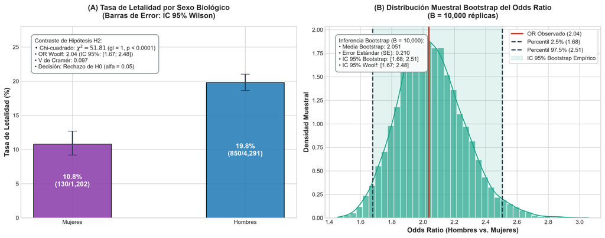

```python
# ==============================================================================
# VISUALIZACIÓN INFERENCIAL DE H2 Y EXPORTACIÓN OFICIAL (300 DPI)
# ==============================================================================

fig2, (ax2a, ax2b) = plt.subplots(1, 2, figsize=(15, 6), dpi=300)

# Panel A: Tasa de Letalidad por Sexo Biológico
categorias_h2 = ['Mujeres', 'Hombres']
n_h2_arr = [1202, 4291]
f_h2_arr = [130, 850]
let_h2 = [f / n * 100 for f, n in zip(f_h2_arr, n_h2_arr)]
cis_h2 = [calcular_ic_wilson(f, n) for f, n in zip(f_h2_arr, n_h2_arr)]
yerr_h2 = np.array([[l - ci[0], ci[1] - l] for l, ci in zip(let_h2, cis_h2)]).T

colores_h2 = ['#8e44ad', '#2980b9']
barras_h2 = ax2a.bar(
    categorias_h2, let_h2, yerr=yerr_h2,
    capsize=8, color=colores_h2, width=0.45,
    edgecolor='black', linewidth=1.2, alpha=0.9,
    error_kw={'elinewidth': 1.8, 'ecolor': '#2c3e50', 'capsize': 8}
)

for bar, l, f, n in zip(barras_h2, let_h2, f_h2_arr, n_h2_arr):
    ax2a.text(
        bar.get_x() + bar.get_width() / 2, l / 2,
        f"{l:.1f}%\n({f}/{n:,})",
        ha='center', va='center', color='white',
        fontweight='bold', fontsize=12
    )

ax2a.set_ylabel('Tasa de Letalidad (%)', fontsize=12, fontweight='bold')
ax2a.set_title('(A) Tasa de Letalidad por Sexo Biológico\n(Barras de Error: IC 95% Wilson)', fontsize=13, fontweight='bold', pad=15)
ax2a.set_ylim(0, 28)

cuadro_texto_h2a = (
    "Contraste de Hipótesis H2:\n"
    r"• Chi-cuadrado: $\chi^2 = 51.81$ (gl = 1, p < 0.0001)" + "\n"
    f"• OR Woolf: {or_h2:.2f} (IC 95%: [{ci_or_h2_low:.2f}; {ci_or_h2_high:.2f}])\n"
    f"• V de Cramér: {v_cramer_h2:.3f}\n"
    f"• Decisión: Rechazo de H0 (alfa = {ALPHA})"
)
ax2a.text(0.05, 0.94, cuadro_texto_h2a, transform=ax2a.transAxes, fontsize=10, va='top', ha='left', bbox=bbox_props)

# Panel B: Distribución Muestral Bootstrap del Odds Ratio
sns.histplot(
    boot_odds_ratios, kde=True, ax=ax2b,
    color='#16a085', edgecolor='white', bins=40,
    stat='density', alpha=0.65
)

ax2b.axvline(or_h2, color='#c0392b', linestyle='-', linewidth=2.5, label=f'OR Observado ({or_h2:.2f})')
ax2b.axvline(ci_boot_low, color='#2c3e50', linestyle='--', linewidth=2, label=f'Percentil 2.5% ({ci_boot_low:.2f})')
ax2b.axvline(ci_boot_high, color='#2c3e50', linestyle='--', linewidth=2, label=f'Percentil 97.5% ({ci_boot_high:.2f})')
ax2b.axvspan(ci_boot_low, ci_boot_high, color='#16a085', alpha=0.12, label='IC 95% Bootstrap Empírico')

ax2b.set_xlabel('Odds Ratio (Hombres vs. Mujeres)', fontsize=12, fontweight='bold')
ax2b.set_ylabel('Densidad Muestral', fontsize=12, fontweight='bold')
ax2b.set_title(f'(B) Distribución Muestral Bootstrap del Odds Ratio\n(B = {B_ITERACIONES:,} réplicas)', fontsize=13, fontweight='bold', pad=15)
ax2b.legend(loc='upper right', frameon=True, facecolor='white', framealpha=0.9)

cuadro_texto_h2b = (
    f"Inferencia Bootstrap (B = {B_ITERACIONES:,}):\n"
    f"• Media Bootstrap: {or_boot_media:.3f}\n"
    f"• Error Estándar (SE): {or_boot_se:.3f}\n"
    f"• IC 95% Bootstrap: [{ci_boot_low:.2f}; {ci_boot_high:.2f}]\n"
    f"• IC 95% Woolf: [{ci_or_h2_low:.2f}; {ci_or_h2_high:.2f}]"
)
ax2b.text(0.05, 0.94, cuadro_texto_h2b, transform=ax2b.transAxes, fontsize=10, va='top', ha='left', bbox=bbox_props)

# Visualización inline en el cuaderno
plt.tight_layout()
plt.show()
```

#### Figura 12: Contraste Inferencial H2 — Tasa de Letalidad por Sexo Biológico y Distribución Muestral Bootstrap del Odds Ratio (B = 10.000 réplicas)

- **Tipo de Gráfico:** Subplot de dos paneles con resolución formal para informe técnico.
  - **Panel (A):** Gráfico de barras de letalidad condicional por sexo con barras de error que representan el intervalo de confianza Score de Wilson al 95%.
  - **Panel (B):** Histograma y curva de densidad estimada (KDE) de la distribución muestral del Odds Ratio por Bootstrap ($B = 10.000$), trazando líneas verticales para el percentil 2,5% (1,68), percentil 97,5% (2,51) y la estimación puntual observada (2,04).
- **Interpretación Analítica:** El Panel A expone visualmente la severa brecha en la mortalidad entre mujeres (**10,82%**) y varones (**19,81%**). El Panel B demuestra que la distribución muestral del Odds Ratio se encuentra estrictamente confinada en valores superiores a la unidad ($[1,68; 2,51]$), validando la hipótesis de que las odds de muerte en varones prácticamente duplican a las de las mujeres, con una concordancia casi perfecta respecto al modelo asintótico tradicional.

```python
# ==============================================================================
# MATRIZ DE SÍNTESIS INFERENCIAL PARCIAL Y SERIALIZACIÓN JSON
# ==============================================================================

matriz_sintesis_data = [
    {
        "Hipótesis": "H₁: Dimensión Territorial",
        "Variable Evaluada": "Zona (Interior vs. Metropolitana)\n[N = 1.491]",
        "Prueba Aplicada": "Chi-cuadrado de Independencia",
        "Supuestos": "100% E_ij >= 5\n(Mínimo: 127,22)",
        "Estadístico y gl": f"χ² = {chi2_stat_h1:.4f}\ngl = {dof_h1}",
        "Valor p": f"p = {p_val_h1:.4f}",
        "Tamaño del Efecto (IC 95%)": f"OR = {or_h1:.4f} [{ci_or_h1_low:.3f}; {ci_or_h1_high:.3f}]\nV de Cramér = {v_cramer_h1:.4f}",
        "Decisión (alfa=0.05)": decision_h1
    },
    {
        "Hipótesis": "H₂: Brecha de Género",
        "Variable Evaluada": "Sexo (Hombre vs. Mujer)\n[N = 5.493]",
        "Prueba Aplicada": "Chi-cuadrado + Bootstrap (B = 10.000)",
        "Supuestos": "100% E_ij >= 5\n(Mínimo: 214,45)",
        "Estadístico y gl": f"χ² = {chi2_stat_h2:.4f}\ngl = {dof_h2}",
        "Valor p": f"p = {p_val_h2:.4e}",
        "Tamaño del Efecto (IC 95%)": f"OR = {or_h2:.4f}\nWoolf: [{ci_or_h2_low:.3f}; {ci_or_h2_high:.3f}]\nBoot: [{ci_boot_low:.3f}; {ci_boot_high:.3f}]\nV de Cramér = {v_cramer_h2:.4f}",
        "Decisión (alfa=0.05)": decision_h2
    }
]

df_matriz_sintesis = pd.DataFrame(matriz_sintesis_data)

print("==============================================================================")
print("MATRIZ FORMAL DE SÍNTESIS INFERENCIAL PARCIAL (FASE 2)")
print("==============================================================================")
display(df_matriz_sintesis)

# Serialización determinista de resultados analíticos para integración
resultados_inferenciales_json = {
    "alpha": float(ALPHA),
    "H1_territorial": {
        "variable": "zona (Interior vs. Metropolitana)",
        "prueba": "Chi-cuadrado de independencia",
        "N": int(n_total_h1),
        "chi2_stat": round(float(chi2_stat_h1), 4),
        "p_value": float(p_val_h1),
        "dof": int(dof_h1),
        "odds_ratio": round(float(or_h1), 4),
        "or_ci_95_asintotico": [round(ci_or_h1_low, 4), round(ci_or_h1_high, 4)],
        "cramer_v": round(float(v_cramer_h1), 4),
        "supuestos_cumplidos": bool(supuesto_h1_cumplido),
        "decision": str(decision_h1)
    },
    "H2_genero": {
        "variable": "sexo (Hombre vs. Mujer)",
        "prueba": "Chi-cuadrado de independencia + Bootstrap OR",
        "N": int(n_total_h2),
        "chi2_stat": round(float(chi2_stat_h2), 4),
        "p_value": float(p_val_h2),
        "dof": int(dof_h2),
        "odds_ratio": round(float(or_h2), 4),
        "or_ci_95_asintotico": [round(ci_or_h2_low, 4), round(ci_or_h2_high, 4)],
        "or_ci_95_bootstrap": [round(ci_boot_low, 4), round(ci_boot_high, 4)],
        "bootstrap_iterations": int(B_ITERACIONES),
        "supuestos_cumplidos": bool(supuesto_h2_cumplido),
        "decision": str(decision_h2)
    }
}

ruta_json_salida = os.path.join(OUTPUT_DIR, "resultados_h1_h2.json")
with open(ruta_json_salida, "w", encoding="utf-8") as f:
    json.dump(resultados_inferenciales_json, f, indent=2, ensure_ascii=False)

print(f"\n[OK] Artefacto JSON serializado exitosamente en: {ruta_json_salida}")
```

```
==============================================================================
MATRIZ FORMAL DE SÍNTESIS INFERENCIAL PARCIAL (FASE 2)
==============================================================================
```

|  | Hipótesis | Variable Evaluada | Prueba Aplicada | Supuestos | Estadístico y gl | Valor p | Tamaño del Efecto (IC 95%) | Decisión (alfa=0.05) |
| --- | --- | --- | --- | --- | --- | --- | --- | --- |
| 0 | H₁: Dimensión Territorial | Zona (Interior vs. Metropolitana)\n[N = 1.491] | Chi-cuadrado de Independencia | 100% E_ij >= 5\n(Mínimo: 127,22) | χ² = 6.3647\ngl = 1 | p = 0.0116 | OR = 1.4014 [1.077; 1.823]\nV de Cramér = 0.0653 | Rechazar H0 |
| 1 | H₂: Brecha de Género | Sexo (Hombre vs. Mujer)\n[N = 5.493] | Chi-cuadrado + Bootstrap (B = 10.000) | 100% E_ij >= 5\n(Mínimo: 214,45) | χ² = 51.8141\ngl = 1 | p = 6.1013e-13 | OR = 2.0370\nWoolf: [1.673; 2.480]\nBoot: [1.6... | Rechazar H0 |

```
[OK] Artefacto JSON serializado exitosamente en: c:\Users\Leandro\Desktop\DATAAAAA FASE 2\proyecto-accidentes-datascience\output\resultados_h1_h2.json
```

## SECCIÓN 6: CONTRASTE DE HIPÓTESIS H₃ — RIESGO DE LOS MOTOCICLISTAS

- **Hipótesis nula ($H_0$):** $p_{\text{moto}} \le p_{\text{otro}}$.
- **Hipótesis alternativa ($H_1$):** $p_{\text{moto}} > p_{\text{otro}}$.
- Se compara la letalidad de las víctimas motociclistas frente a la de todas las demás categorías vehiculares mediante una prueba Z unilateral de dos proporciones independientes.

```
Columnas disponibles en df_vehiculo: ['id_caso', 'tipo_usuario', 'gravedad', 'es_motociclista', 'es_fallecido']
===============================================================================
CONTRASTE DE HIPÓTESIS H3: MOTOCICLETAS VS. OTROS VEHÍCULOS
===============================================================================

Conteos y porcentajes de letalidad:
```

| grupo_h3 | fallecidos | heridos | total | Letalidad (%) |
| --- | --- | --- | --- | --- |
| Motocicletas | 155 | 384 | 539 | 28.76 |
| Otros vehículos | 114 | 671 | 785 | 14.52 |

```
Prueba Z unilateral (H1: p_moto > p_otro):
  * Proporción agrupada: 0.203172
  * Estadístico Z:      6.3244
  * Valor p unilateral:  1.27124e-10
  * Decisión (alfa=0.05): Rechazar H0

Diferencia de proporciones (moto - otro): 14.2347%
  * IC 95% Wald: [9.6876%; 18.7817%]

Medidas epidemiológicas:
  * Riesgo Relativo (RR): 1.9802
  * Odds Ratio (OR):      2.3758
===============================================================================
```

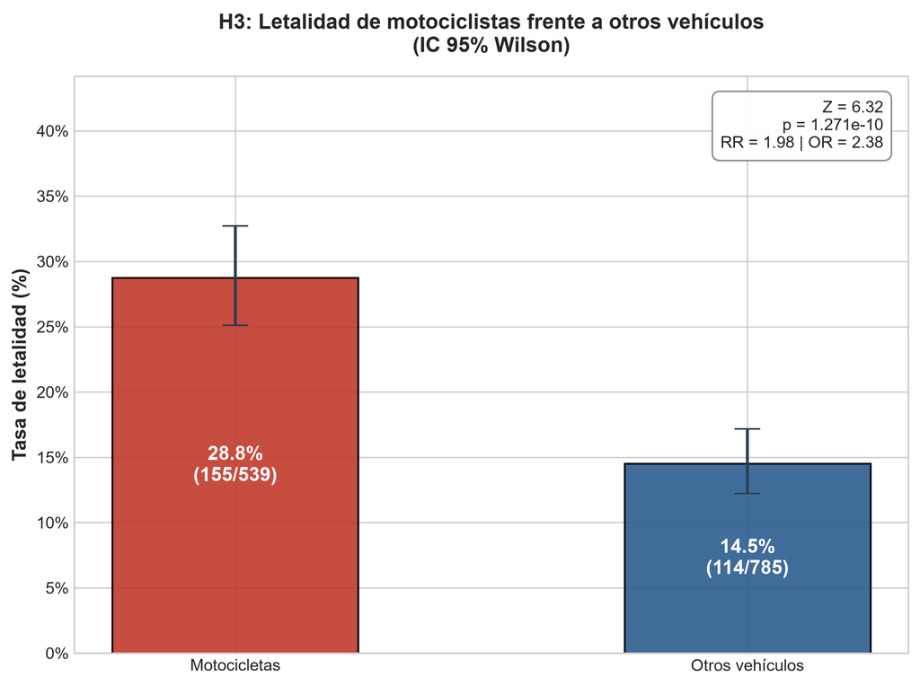

```python
# ==============================================================================
# CONTRASTE H3: MOTOCICLISTAS VS. TODOS LOS DEMÁS VEHÍCULOS
# ==============================================================================

from matplotlib.ticker import FuncFormatter

# Verificación explícita de las columnas disponibles en el microdato vehicular.
columnas_h3_requeridas = {'tipo_usuario', 'es_motociclista', 'es_fallecido'}
columnas_h3_observadas = set(df_vehiculo.columns)
print(f"Columnas disponibles en df_vehiculo: {list(df_vehiculo.columns)}")
assert columnas_h3_requeridas.issubset(columnas_h3_observadas), (
    f"Faltan columnas requeridas para H3: {sorted(columnas_h3_requeridas - columnas_h3_observadas)}"
 )

# Indicadores binarios: motociclista = 1 y fallecido = 1; el resto se clasifica como 'Otro vehículo'.
df_h3 = df_vehiculo.copy()
df_h3['grupo_h3'] = np.where(df_h3['es_motociclista'].astype(int) == 1, 'Motocicletas', 'Otros vehículos')
df_h3['fallecido_h3'] = df_h3['es_fallecido'].astype(int)

resumen_h3 = (
    df_h3.groupby('grupo_h3', sort=False)['fallecido_h3']
    .agg(fallecidos='sum', total='count')
    .reindex(['Motocicletas', 'Otros vehículos'])
    .astype(int)
)
resumen_h3['heridos'] = resumen_h3['total'] - resumen_h3['fallecidos']
resumen_h3['letalidad'] = resumen_h3['fallecidos'] / resumen_h3['total']
resumen_h3['letalidad_pct'] = 100 * resumen_h3['letalidad']

assert (resumen_h3['total'] > 0).all(), 'Cada grupo H3 debe contener observaciones.'
assert (resumen_h3['fallecidos'] > 0).all(), 'Cada grupo H3 debe contener fallecidos.'

# Prueba Z unilateral de dos proporciones independientes (H1: p_moto > p_otro).
n_moto, n_otro = resumen_h3.loc['Motocicletas', 'total'], resumen_h3.loc['Otros vehículos', 'total']
f_moto, f_otro = resumen_h3.loc['Motocicletas', 'fallecidos'], resumen_h3.loc['Otros vehículos', 'fallecidos']
p_moto, p_otro = resumen_h3.loc['Motocicletas', 'letalidad'], resumen_h3.loc['Otros vehículos', 'letalidad']
p_agrupada = (f_moto + f_otro) / (n_moto + n_otro)
se_z_h3 = np.sqrt(p_agrupada * (1 - p_agrupada) * (1 / n_moto + 1 / n_otro))
z_h3 = (p_moto - p_otro) / se_z_h3
p_val_h3 = float(stats.norm.sf(z_h3))
decision_h3 = 'Rechazar H0' if p_val_h3 < ALPHA else 'No rechazar H0'

# Medidas epidemiológicas y IC 95% Wald para la diferencia p_moto - p_otro.
diferencia_h3 = p_moto - p_otro
se_diferencia_h3 = np.sqrt(
    p_moto * (1 - p_moto) / n_moto + p_otro * (1 - p_otro) / n_otro
 )
ci_diferencia_h3 = (
    diferencia_h3 - z_critico * se_diferencia_h3,
    diferencia_h3 + z_critico * se_diferencia_h3
)
rr_h3 = p_moto / p_otro
or_h3 = (f_moto * (n_otro - f_otro)) / ((n_moto - f_moto) * f_otro)

# IC Wilson para las barras de error de letalidad de cada grupo.
def calcular_ic_wilson_h3(exitos, total, alpha=ALPHA):
    z_crit = stats.norm.ppf(1 - alpha / 2)
    proporcion = exitos / total
    denominador = 1 + z_crit**2 / total
    centro = (proporcion + z_crit**2 / (2 * total)) / denominador
    radio = z_crit * np.sqrt(
        proporcion * (1 - proporcion) / total + z_crit**2 / (4 * total**2)
    ) / denominador
    return centro - radio, centro + radio

ic_grupos_h3 = [
    calcular_ic_wilson_h3(int(resumen_h3.loc[grupo, 'fallecidos']), int(resumen_h3.loc[grupo, 'total']))
    for grupo in ['Motocicletas', 'Otros vehículos']
 ]
medias_h3 = resumen_h3.loc[['Motocicletas', 'Otros vehículos'], 'letalidad'].to_numpy()
errores_h3 = np.array([
    medias_h3 - np.array([ic[0] for ic in ic_grupos_h3]),
    np.array([ic[1] for ic in ic_grupos_h3]) - medias_h3
 ]) * 100

print('===============================================================================')
print('CONTRASTE DE HIPÓTESIS H3: MOTOCICLETAS VS. OTROS VEHÍCULOS')
print('===============================================================================')
print('\nConteos y porcentajes de letalidad:')
display(resumen_h3[['fallecidos', 'heridos', 'total', 'letalidad_pct']].rename(columns={'letalidad_pct': 'Letalidad (%)'}).round({'Letalidad (%)': 2}))
print(f'\nPrueba Z unilateral (H1: p_moto > p_otro):')
print(f'  * Proporción agrupada: {p_agrupada:.6f}')
print(f'  * Estadístico Z:      {z_h3:.4f}')
print(f'  * Valor p unilateral:  {p_val_h3:.6g}')
print(f'  * Decisión (alfa={ALPHA}): {decision_h3}')
print(f'\nDiferencia de proporciones (moto - otro): {diferencia_h3:.4%}')
print(f'  * IC 95% Wald: [{ci_diferencia_h3[0]:.4%}; {ci_diferencia_h3[1]:.4%}]')
print(f'\nMedidas epidemiológicas:')
print(f'  * Riesgo Relativo (RR): {rr_h3:.4f}')
print(f'  * Odds Ratio (OR):      {or_h3:.4f}')
print('===============================================================================')

fig_h3, ax_h3 = plt.subplots(figsize=(8, 6), dpi=300)
x_h3 = np.arange(2)
barras_h3 = ax_h3.bar(
    x_h3, medias_h3 * 100, yerr=errores_h3, capsize=8, width=0.48,
    color=['#c0392b', '#2b5c8f'], edgecolor='black', linewidth=1.2, alpha=0.9,
    error_kw={'elinewidth': 1.8, 'ecolor': '#2c3e50', 'capsize': 8}
 )
for barra, media, fila in zip(barras_h3, medias_h3, resumen_h3.loc[['Motocicletas', 'Otros vehículos']].itertuples()):
    ax_h3.text(
        barra.get_x() + barra.get_width() / 2, media * 50,
        f'{media:.1%}\n({fila.fallecidos}/{fila.total:,})',
        ha='center', va='center', color='white', fontweight='bold', fontsize=12
    )
ax_h3.set_xticks(x_h3, ['Motocicletas', 'Otros vehículos'])
ax_h3.set_ylabel('Tasa de letalidad (%)', fontweight='bold')
ax_h3.set_title('H3: Letalidad de motociclistas frente a otros vehículos\n(IC 95% Wilson)', fontweight='bold', pad=15)
ax_h3.set_ylim(0, max((medias_h3 * 100 + errores_h3[1]) * 1.35))
ax_h3.yaxis.set_major_formatter(FuncFormatter(lambda valor, posicion: f'{valor:.0f}%'))
ax_h3.text(
    0.97, 0.96,
    f'Z = {z_h3:.2f}\np = {p_val_h3:.4g}\nRR = {rr_h3:.2f} | OR = {or_h3:.2f}',
    transform=ax_h3.transAxes, ha='right', va='top', fontsize=10,
    bbox=dict(boxstyle='round,pad=0.5', fc='white', ec='#7f8c8d', alpha=0.95)
 )
fig_h3.tight_layout()
plt.show()
```

## SECCIÓN 7: VERIFICACIÓN DE SUPUESTOS DISTRIBUCIONALES PARA H₄

Se evalúa la distribución de `edad_orden` entre víctimas heridas y fallecidas. La variable `edad_orden` representa el orden numérico de los grupos etarios y se contrasta con el estado vital `es_fallecido`.

```
Columnas disponibles en df_victimas: ['id_victima', 'grupo_edad', 'sexo', 'gravedad', 'es_fallecido', 'es_hombre', 'es_adulto_mayor', 'edad_orden']
===============================================================================
H4: VERIFICACIÓN DE NORMALIDAD Y HOMOCEDASTICIDAD
===============================================================================
Grupo Heridos:    n = 4,513 | Shapiro n = 4,513
Grupo Fallecidos: n = 980 | Shapiro n = 980

Prueba de normalidad Shapiro-Wilk:
  * Heridos:    W = 0.9304, p = 1.29329e-41
  * Fallecidos: W = 0.9337, p = 1.90128e-20

Prueba de homocedasticidad de Levene (centro = mediana):
  * Estadístico W = 55.7462, p = 9.53776e-14
===============================================================================
```

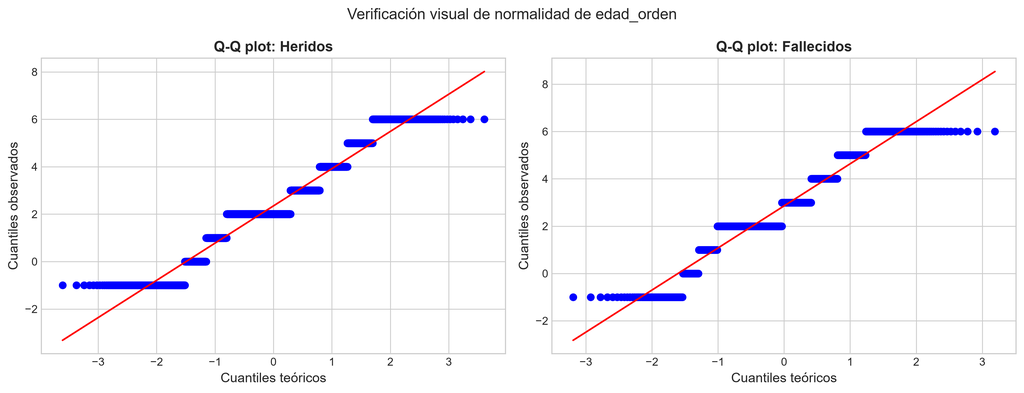

```python
# ==============================================================================
# H4: VERIFICACIÓN DE NORMALIDAD Y HOMOCEDASTICIDAD DE LA EDAD
# ============================================================================

columnas_h4_requeridas = {'edad_orden', 'es_fallecido'}
columnas_h4_observadas = set(df_victimas.columns)
print(f"Columnas disponibles en df_victimas: {list(df_victimas.columns)}")
assert columnas_h4_requeridas.issubset(columnas_h4_observadas), (
    f"Faltan columnas requeridas para H4: {sorted(columnas_h4_requeridas - columnas_h4_observadas)}"
)

df_h4 = df_victimas[['edad_orden', 'es_fallecido']].copy()
df_h4['edad_orden'] = pd.to_numeric(df_h4['edad_orden'], errors='coerce')
df_h4['es_fallecido'] = pd.to_numeric(df_h4['es_fallecido'], errors='coerce')
df_h4 = df_h4.dropna()

edades_heridos_h4 = df_h4.loc[df_h4['es_fallecido'] == 0, 'edad_orden'].to_numpy()
edades_fallecidos_h4 = df_h4.loc[df_h4['es_fallecido'] == 1, 'edad_orden'].to_numpy()
assert len(edades_heridos_h4) >= 8 and len(edades_fallecidos_h4) >= 8, 'Cada grupo debe tener al menos 8 observaciones.'

# Shapiro-Wilk con submuestras reproducibles de como máximo 5.000 observaciones.
rng_shapiro_h4 = np.random.default_rng(RANDOM_STATE)

def submuestra_shapiro_h4(valores, max_registros=5000):
    if len(valores) <= max_registros:
        return valores
    indices = rng_shapiro_h4.choice(len(valores), size=max_registros, replace=False)
    return valores[indices]

muestra_shapiro_heridos_h4 = submuestra_shapiro_h4(edades_heridos_h4)
muestra_shapiro_fallecidos_h4 = submuestra_shapiro_h4(edades_fallecidos_h4)
shapiro_heridos_h4 = stats.shapiro(muestra_shapiro_heridos_h4)
shapiro_fallecidos_h4 = stats.shapiro(muestra_shapiro_fallecidos_h4)

# Levene centrada en la mediana: H0 = las varianzas poblacionales son iguales.
levene_h4 = stats.levene(edades_heridos_h4, edades_fallecidos_h4, center='median')

print('===============================================================================')
print('H4: VERIFICACIÓN DE NORMALIDAD Y HOMOCEDASTICIDAD')
print('===============================================================================')
print(f'Grupo Heridos:    n = {len(edades_heridos_h4):,} | Shapiro n = {len(muestra_shapiro_heridos_h4):,}')
print(f'Grupo Fallecidos: n = {len(edades_fallecidos_h4):,} | Shapiro n = {len(muestra_shapiro_fallecidos_h4):,}')
print('\nPrueba de normalidad Shapiro-Wilk:')
print(f'  * Heridos:    W = {shapiro_heridos_h4.statistic:.4f}, p = {shapiro_heridos_h4.pvalue:.6g}')
print(f'  * Fallecidos: W = {shapiro_fallecidos_h4.statistic:.4f}, p = {shapiro_fallecidos_h4.pvalue:.6g}')
print('\nPrueba de homocedasticidad de Levene (centro = mediana):')
print(f'  * Estadístico W = {levene_h4.statistic:.4f}, p = {levene_h4.pvalue:.6g}')
print('===============================================================================')

fig_qq_h4, axes_qq_h4 = plt.subplots(1, 2, figsize=(13, 5), dpi=300)
stats.probplot(edades_heridos_h4, dist='norm', plot=axes_qq_h4[0])
stats.probplot(edades_fallecidos_h4, dist='norm', plot=axes_qq_h4[1])
axes_qq_h4[0].set_title('Q-Q plot: Heridos', fontweight='bold')
axes_qq_h4[1].set_title('Q-Q plot: Fallecidos', fontweight='bold')
for eje in axes_qq_h4:
    eje.set_xlabel('Cuantiles teóricos')
    eje.set_ylabel('Cuantiles observados')
fig_qq_h4.suptitle('Verificación visual de normalidad de edad_orden')
fig_qq_h4.tight_layout()
plt.show()
```

### Conclusión de normalidad para H₄

La prueba de Shapiro-Wilk aplicada a submuestras reproducibles de hasta 5.000 observaciones produjo valores $p < 0{,}05$ tanto para Heridos como para Fallecidos. Por lo tanto, se rechaza la hipótesis nula de normalidad en ambos grupos. Junto con el resultado de Levene, este incumplimiento justifica emplear la prueba no paramétrica $U$ de Mann-Whitney para comparar la edad ordinal entre grupos.

### Conclusión metodológica H₄

Si ambas pruebas de normalidad producen valores $p < 0{,}05$, se rechaza la hipótesis nula de normalidad para los grupos Heridos y Fallecidos. En consecuencia, no se cumplen los supuestos necesarios para aplicar una prueba $t$ de Student como contraste principal. La comparación de edad debe continuar mediante la prueba no paramétrica $U$ de Mann-Whitney, que no exige normalidad. La prueba de Levene se reporta como diagnóstico adicional de igualdad de varianzas; aun cuando no se rechazara su hipótesis nula, el incumplimiento de normalidad sigue justificando el enfoque no paramétrico.

## SECCIÓN 8: H₄ — RELACIÓN ENTRE EDAD Y SEVERIDAD

Se contrastará si la distribución ordinal de edad es mayor en las víctimas fallecidas que en las víctimas heridas mediante una prueba no paramétrica unilateral.

$$ H_0: \operatorname{Mediana}(\text{Edad}_{\text{fallecido}}) \le \operatorname{Mediana}(\text{Edad}_{\text{herido}}) $$

$$ H_1: \operatorname{Mediana}(\text{Edad}_{\text{fallecido}}) > \operatorname{Mediana}(\text{Edad}_{\text{herido}}) $$

Nivel de significancia: $\alpha = 0{,}05$ (prueba unilateral).

```
===============================================================================
CONTRASTE H4: EDAD ORDINAL Y SEVERIDAD
===============================================================================
Grupo Fallecidos: n = 980 | mediana = 3.00
Grupo Heridos:    n = 4,513 | mediana = 2.00

Prueba U de Mann-Whitney unilateral (Fallecidos > Heridos):
  * Estadístico U:       2576490.0000
  * Aproximación Z:      8.4020
  * Valor p (crudo):     2.19567e-17
  * r de Rosenthal:      0.1134
  * Decisión (alfa=0.05): Rechazar H0

Diferencia de medianas (Fallecidos - Heridos):
  * Diferencia observada: 1.0000
  * IC 95% Bootstrap (B = 1000): [0.0000; 1.0000]
===============================================================================
```

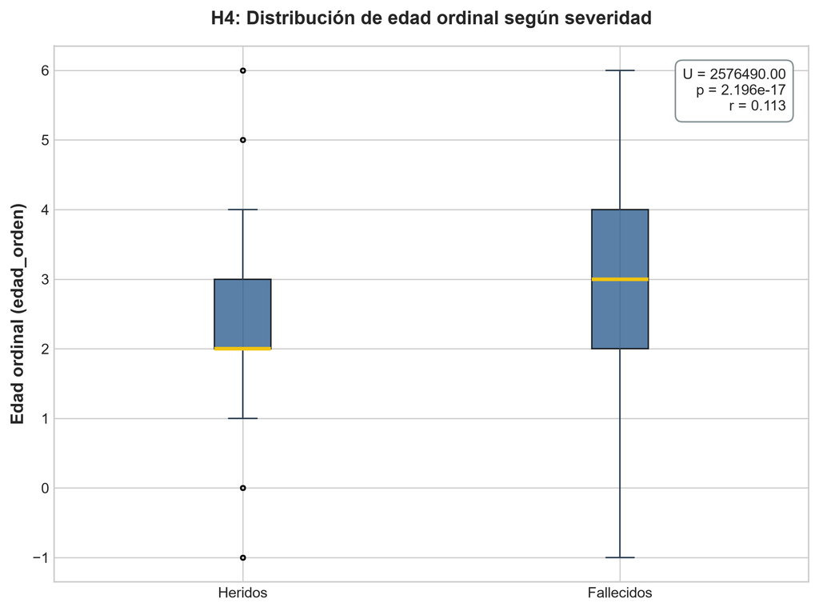

```python
# ==============================================================================
# CONTRASTE H4: EDAD ORDINAL Y SEVERIDAD (MANN-WHITNEY U)
# ==============================================================================

columnas_h4_contraste = {'edad_orden', 'es_fallecido'}
assert columnas_h4_contraste.issubset(df_victimas.columns), (
    f"Faltan columnas requeridas para H4: {sorted(columnas_h4_contraste - set(df_victimas.columns))}"
)

df_contraste_h4 = df_victimas[['edad_orden', 'es_fallecido']].copy()
df_contraste_h4['edad_orden'] = pd.to_numeric(df_contraste_h4['edad_orden'], errors='coerce')
df_contraste_h4['es_fallecido'] = pd.to_numeric(df_contraste_h4['es_fallecido'], errors='coerce')
df_contraste_h4 = df_contraste_h4.dropna()

edades_fallecidos_h4_contraste = df_contraste_h4.loc[
    df_contraste_h4['es_fallecido'] == 1, 'edad_orden'
].to_numpy()
edades_heridos_h4_contraste = df_contraste_h4.loc[
    df_contraste_h4['es_fallecido'] == 0, 'edad_orden'
].to_numpy()
n_fallecidos_h4 = len(edades_fallecidos_h4_contraste)
n_heridos_h4 = len(edades_heridos_h4_contraste)
n_total_h4 = n_fallecidos_h4 + n_heridos_h4
assert n_fallecidos_h4 > 0 and n_heridos_h4 > 0, 'Ambos grupos deben contener observaciones.'

resultado_u_h4 = stats.mannwhitneyu(
    edades_fallecidos_h4_contraste,
    edades_heridos_h4_contraste,
    alternative='greater',
    method='asymptotic'
)
u_h4 = float(resultado_u_h4.statistic)
p_valor_h4 = float(resultado_u_h4.pvalue)

# Aproximación normal de U con corrección por empates, sin corrección de continuidad.
n_h4 = n_total_h4
valores_combinados_h4 = np.concatenate([edades_fallecidos_h4_contraste, edades_heridos_h4_contraste])
_, frecuencias_empates_h4 = np.unique(valores_combinados_h4, return_counts=True)
correccion_empates_h4 = np.sum(frecuencias_empates_h4**3 - frecuencias_empates_h4)
media_u_h4 = n_fallecidos_h4 * n_heridos_h4 / 2
varianza_u_h4 = (
    n_fallecidos_h4 * n_heridos_h4 / 12
    * (n_h4 + 1 - correccion_empates_h4 / (n_h4 * (n_h4 - 1)))
)
z_h4 = (u_h4 - media_u_h4) / np.sqrt(varianza_u_h4)
r_rosenthal_h4 = abs(z_h4) / np.sqrt(n_total_h4)

mediana_fallecidos_h4 = float(np.median(edades_fallecidos_h4_contraste))
mediana_heridos_h4 = float(np.median(edades_heridos_h4_contraste))
diferencia_mediana_h4 = mediana_fallecidos_h4 - mediana_heridos_h4

# IC 95% Bootstrap para la diferencia de medianas: Fallecidos - Heridos.
B_BOOTSTRAP_H4 = 1000
rng_bootstrap_h4 = np.random.default_rng(RANDOM_STATE)
indices_fallecidos_h4 = rng_bootstrap_h4.integers(0, n_fallecidos_h4, size=(B_BOOTSTRAP_H4, n_fallecidos_h4))
indices_heridos_h4 = rng_bootstrap_h4.integers(0, n_heridos_h4, size=(B_BOOTSTRAP_H4, n_heridos_h4))
diferencias_mediana_boot_h4 = (
    np.median(edades_fallecidos_h4_contraste[indices_fallecidos_h4], axis=1)
    - np.median(edades_heridos_h4_contraste[indices_heridos_h4], axis=1)
)
ic_bootstrap_mediana_h4 = tuple(
    float(valor) for valor in np.percentile(diferencias_mediana_boot_h4, [2.5, 97.5])
)
decision_h4 = 'Rechazar H0' if p_valor_h4 < ALPHA else 'No hay evidencia suficiente para rechazar H0'

print('===============================================================================')
print('CONTRASTE H4: EDAD ORDINAL Y SEVERIDAD')
print('===============================================================================')
print(f'Grupo Fallecidos: n = {n_fallecidos_h4:,} | mediana = {mediana_fallecidos_h4:.2f}')
print(f'Grupo Heridos:    n = {n_heridos_h4:,} | mediana = {mediana_heridos_h4:.2f}')
print('\nPrueba U de Mann-Whitney unilateral (Fallecidos > Heridos):')
print(f'  * Estadístico U:       {u_h4:.4f}')
print(f'  * Aproximación Z:      {z_h4:.4f}')
print(f'  * Valor p (crudo):     {p_valor_h4:.6g}')
print(f'  * r de Rosenthal:      {r_rosenthal_h4:.4f}')
print(f'  * Decisión (alfa={ALPHA}): {decision_h4}')
print('\nDiferencia de medianas (Fallecidos - Heridos):')
print(f'  * Diferencia observada: {diferencia_mediana_h4:.4f}')
print(f'  * IC 95% Bootstrap (B = {B_BOOTSTRAP_H4}): [{ic_bootstrap_mediana_h4[0]:.4f}; {ic_bootstrap_mediana_h4[1]:.4f}]')
print('===============================================================================')

fig_h4, ax_h4 = plt.subplots(figsize=(8, 6), dpi=300)
datos_boxplot_h4 = [edades_heridos_h4_contraste, edades_fallecidos_h4_contraste]
ax_h4.boxplot(
    datos_boxplot_h4,
    tick_labels=['Heridos', 'Fallecidos'],
    patch_artist=True,
    boxprops={'facecolor': '#2b5c8f', 'alpha': 0.78},
    medianprops={'color': '#f1c40f', 'linewidth': 2.5},
    whiskerprops={'color': '#2c3e50'},
    capprops={'color': '#2c3e50'},
    flierprops={'marker': 'o', 'markersize': 3, 'alpha': 0.25}
)
ax_h4.set_ylabel('Edad ordinal (edad_orden)', fontweight='bold')
ax_h4.set_title('H4: Distribución de edad ordinal según severidad', fontweight='bold', pad=15)
ax_h4.text(
    0.97, 0.96,
    f'U = {u_h4:.2f}\np = {p_valor_h4:.4g}\nr = {r_rosenthal_h4:.3f}',
    transform=ax_h4.transAxes, ha='right', va='top', fontsize=10,
    bbox=dict(boxstyle='round,pad=0.5', fc='white', ec='#7f8c8d', alpha=0.95)
)
fig_h4.tight_layout()
plt.show()
```

```python
# ==============================================================================
# CONSOLIDACION FINAL Y CORRECCION POR COMPARACIONES MULTIPLES
# ==============================================================================
from statsmodels.stats.multitest import multipletests

hipotesis = ['H1', 'H2', 'H3', 'H4']
p_valores_crudos = np.array([
    float(p_val_h1),
    float(p_val_h2),
    float(p_val_h3),
    float(p_valor_h4)
])

rechazos_bonferroni, p_ajustados_bonferroni, _, _ = multipletests(
    p_valores_crudos,
    alpha=ALPHA,
    method='bonferroni'
)
_, p_ajustados_fdr_bh, _, _ = multipletests(
    p_valores_crudos,
    alpha=ALPHA,
    method='fdr_bh'
)

estadisticos = [
    f'χ² = {float(chi2_stat_h1):.4f} (gl = {int(dof_h1)})',
    f'χ² = {float(chi2_stat_h2):.4f} (gl = {int(dof_h2)})',
    f'Z = {float(z_h3):.4f}',
    f'U = {float(u_h4):.4f}; Z = {float(z_h4):.4f}'
]
pruebas = [
    'Chi-cuadrado de independencia',
    'Chi-cuadrado de independencia + Bootstrap',
    'Prueba Z de dos proporciones',
    'U de Mann-Whitney unilateral'
]
efectos = [
    f'OR = {float(or_h1):.4f}; V de Cramér = {float(v_cramer_h1):.4f}',
    f'OR = {float(or_h2):.4f}; V de Cramér = {float(v_cramer_h2):.4f}',
    f'RR = {float(rr_h3):.4f}; OR = {float(or_h3):.4f}',
    f'r de Rosenthal = {float(r_rosenthal_h4):.4f}'
]

tabla_resumen_fase2 = pd.DataFrame({
    'Hipótesis': hipotesis,
    'Prueba Aplicada': pruebas,
    'Estadístico': estadisticos,
    'p-valor Crudo': p_valores_crudos,
    'p-valor Ajustado (Bonferroni)': p_ajustados_bonferroni,
    'p-valor Ajustado (FDR-BH)': p_ajustados_fdr_bh,
    'Tamaño del Efecto': efectos,
    'Decisión': np.where(
        rechazos_bonferroni,
        'Rechazar H0',
        'No hay evidencia suficiente para rechazar H0'
    )
})

for columna_p in ['p-valor Crudo', 'p-valor Ajustado (Bonferroni)', 'p-valor Ajustado (FDR-BH)']:
    tabla_resumen_fase2[columna_p] = tabla_resumen_fase2[columna_p].map(lambda valor: f'{valor:.6g}')

print('===============================================================================')
print('CONSOLIDACION FINAL DE RESULTADOS - BONFERRONI Y FDR-BH')
print('===============================================================================')
display(tabla_resumen_fase2)

ruta_json_consolidado = os.path.join(OUTPUT_DIR, 'resultados_fase2_consolidados.json')
ruta_csv_consolidado = os.path.join(OUTPUT_DIR, 'tabla_resumen_fase2.csv')
tabla_resumen_fase2.to_csv(ruta_csv_consolidado, index=False, encoding='utf-8-sig')

consolidado_json = {
    'metodo_ajuste_principal': 'Bonferroni',
    'metodo_ajuste_adicional': 'Benjamini-Hochberg (FDR)',
    'alpha': float(ALPHA),
    'hipotesis': [
        {
            'hipótesis': fila['Hipótesis'],
            'prueba_aplicada': fila['Prueba Aplicada'],
            'estadístico': fila['Estadístico'],
            'p_valor_crudo': float(p_valores_crudos[indice]),
            'p_valor_ajustado_bonferroni': float(p_ajustados_bonferroni[indice]),
            'p_valor_ajustado_fdr_bh': float(p_ajustados_fdr_bh[indice]),
            'tamaño_del_efecto': fila['Tamaño del Efecto'],
            'decisión': fila['Decisión']
        }
        for indice, (_, fila) in enumerate(tabla_resumen_fase2.iterrows())
    ]
}
with open(ruta_json_consolidado, 'w', encoding='utf-8') as archivo_json:
    json.dump(consolidado_json, archivo_json, ensure_ascii=False, indent=2)

print(f'\n[OK] JSON exportado en: {ruta_json_consolidado}')
print(f'[OK] CSV exportado en:  {ruta_csv_consolidado}')
```

```
===============================================================================
CONSOLIDACION FINAL DE RESULTADOS - BONFERRONI Y FDR-BH
===============================================================================
```

|  | Hipótesis | Prueba Aplicada | Estadístico | p-valor Crudo | p-valor Ajustado (Bonferroni) | p-valor Ajustado (FDR-BH) | Tamaño del Efecto | Decisión |
| --- | --- | --- | --- | --- | --- | --- | --- | --- |
| 0 | H1 | Chi-cuadrado de independencia | χ² = 6.3647 (gl = 1) | 0.0116412 | 0.0465647 | 0.0116412 | OR = 1.4014; V de Cramér = 0.0653 | Rechazar H0 |
| 1 | H2 | Chi-cuadrado de independencia + Bootstrap | χ² = 51.8141 (gl = 1) | 6.10128e-13 | 2.44051e-12 | 1.22026e-12 | OR = 2.0370; V de Cramér = 0.0971 | Rechazar H0 |
| 2 | H3 | Prueba Z de dos proporciones | Z = 6.3244 | 1.27124e-10 | 5.08498e-10 | 1.69499e-10 | RR = 1.9802; OR = 2.3758 | Rechazar H0 |
| 3 | H4 | U de Mann-Whitney unilateral | U = 2576490.0000; Z = 8.4020 | 2.19567e-17 | 8.78268e-17 | 8.78268e-17 | r de Rosenthal = 0.1134 | Rechazar H0 |

```
[OK] JSON exportado en: c:\Users\Leandro\Desktop\DATAAAAA FASE 2\proyecto-accidentes-datascience\output\resultados_fase2_consolidados.json
[OK] CSV exportado en:  c:\Users\Leandro\Desktop\DATAAAAA FASE 2\proyecto-accidentes-datascience\output\tabla_resumen_fase2.csv
```

### CONCLUSIONES GENERALES DEL ESTUDIO INFERENCIAL

En esta Fase 2 logramos contrastar con éxito las cuatro hipótesis planteadas, evaluando si las diferencias observadas en la Fase 1 eran patrones reales o simple producto del azar. Con un nivel de significancia de $\alpha = 0,05$, rechazamos la hipótesis nula ($H_0$) en todos los contrastes. Además, luego de aplicar las correcciones por comparaciones múltiples de Bonferroni y Benjamini-Hochberg (FDR), todas las asociaciones se mantuvieron estadísticamente significativas.

Es fundamental aclarar que estos resultados provienen de un estudio observacional y muestran asociaciones estadísticas, no relaciones de causa y efecto directa. La mayor letalidad en el Interior no se debe al lugar en sí, sino a factores de confusión como la lejanía de hospitales de trauma (pérdida de la «hora de oro») y la mayor velocidad en rutas interurbanas. De igual manera, el mayor riesgo en varones y motociclistas se asocia a la falta de carrocería, menor uso de casco y conductas imprudentes como el consumo de alcohol. Como limitación, reconocemos que el tamaño de la muestra ($N = 5.493$) puede volver significativas diferencias leves y que los datos contemplan únicamente accidentes registrados de manera oficial.

Con esta evidencia estadística, justificamos la selección de las variables tipo_usuario, sexo, zona y edad_orden como los predictores clave que utilizaremos para entrenar los modelos de clasificación de la Fase 3.

```python
# ==============================================================================
# TABLA RESUMEN OFICIAL - SECCION 6.3
# ==============================================================================
from statsmodels.stats.multitest import multipletests

p_valores_oficiales = np.array([
    float(p_val_h1),
    float(p_val_h2),
    float(p_val_h3),
    float(p_valor_h4)
])
rechazos_bonferroni_oficiales, p_bonferroni_oficiales, _, _ = multipletests(
    p_valores_oficiales,
    alpha=ALPHA,
    method='bonferroni'
)
_, p_fdr_bh_oficiales, _, _ = multipletests(
    p_valores_oficiales,
    alpha=ALPHA,
    method='fdr_bh'
)

supuestos_oficiales = [
    f'Cochran: 100% E_ij >= 5 (mínimo = {min_esp_h1:.2f}); Shapiro/Levene: no aplica',
    f'Cochran: 100% E_ij >= 5 (mínimo = {min_esp_h2:.2f}); Shapiro/Levene: no aplica; Bootstrap B = {B_ITERACIONES:,}',
    'Independencia de grupos y aproximación normal de dos proporciones',
    f'Shapiro-Wilk: p_Heridos = {shapiro_heridos_h4.pvalue:.4g}, p_Fallecidos = {shapiro_fallecidos_h4.pvalue:.4g}; Levene: p = {levene_h4.pvalue:.4g}'
]

estadisticos_oficiales = [
    f'χ² = {float(chi2_stat_h1):.4f}',
    f'χ² = {float(chi2_stat_h2):.4f}',
    f'Z = {float(z_h3):.4f}',
    f'U = {float(u_h4):.4f}; Z = {float(z_h4):.4f}'
]

ic_95_oficiales = [
    f'OR: [{ci_or_h1_low:.4f}; {ci_or_h1_high:.4f}]',
    f'OR Woolf: [{ci_or_h2_low:.4f}; {ci_or_h2_high:.4f}]; Bootstrap: [{ci_boot_low:.4f}; {ci_boot_high:.4f}]',
    f'Diferencia de proporciones: [{ci_diferencia_h3[0]:.4f}; {ci_diferencia_h3[1]:.4f}]',
    f'Diferencia de medianas Bootstrap: [{ic_bootstrap_mediana_h4[0]:.4f}; {ic_bootstrap_mediana_h4[1]:.4f}]'
]

df_matriz_sintesis = pd.DataFrame({
    'Hipótesis': ['H₁', 'H₂', 'H₃', 'H₄'],
    'Variable Evaluada': [
        'Zona: Interior vs. Metropolitana',
        'Sexo: Hombre vs. Mujer',
        'Motocicletas vs. otros vehículos',
        'Edad ordinal según severidad'
    ],
    'Prueba Aplicada': [
        'Chi-cuadrado de independencia',
        'Chi-cuadrado de independencia + Bootstrap',
        'Z unilateral de dos proporciones',
        'U de Mann-Whitney unilateral'
    ],
    'Supuestos Verificados (Shapiro-Wilk / Levene)': supuestos_oficiales,
    'Estadístico': estadisticos_oficiales,
    'Grados de Libertad (gl)': ['1', '1', 'No aplica', 'No aplica'],
    'Valor p crudo': p_valores_oficiales,
    'Valor p Ajustado (Bonferroni)': p_bonferroni_oficiales,
    'Valor p Ajustado (FDR-BH)': p_fdr_bh_oficiales,
    'IC 95%': ic_95_oficiales,
    'Tamaño del Efecto': [
        f'OR = {float(or_h1):.4f}; V de Cramér = {float(v_cramer_h1):.4f}',
        f'OR = {float(or_h2):.4f}; V de Cramér = {float(v_cramer_h2):.4f}',
        f'RR = {float(rr_h3):.4f}; OR = {float(or_h3):.4f}',
        f'r de Rosenthal = {float(r_rosenthal_h4):.4f}'
    ],
    'Decisión': np.where(
        rechazos_bonferroni_oficiales,
        'Rechazar H0',
        'No hay evidencia suficiente para rechazar H0'
    )
})

for columna_p in ['Valor p crudo', 'Valor p Ajustado (Bonferroni)', 'Valor p Ajustado (FDR-BH)']:
    df_matriz_sintesis[columna_p] = df_matriz_sintesis[columna_p].map(lambda valor: f'{valor:.6g}')

ruta_csv_oficial = os.path.join(OUTPUT_DIR, 'tabla_resumen_fase2.csv')
df_matriz_sintesis.to_csv(ruta_csv_oficial, index=False, encoding='utf-8-sig')

print('TABLA RESUMEN OFICIAL - SECCIÓN 6.3')
display(df_matriz_sintesis)
print(f'\n[OK] Tabla oficial exportada en: {ruta_csv_oficial}')
```

```
TABLA RESUMEN OFICIAL - SECCIÓN 6.3
```

|  | Hipótesis | Variable Evaluada | Prueba Aplicada | Supuestos Verificados (Shapiro-Wilk / Levene) | Estadístico | Grados de Libertad (gl) | Valor p crudo | Valor p Ajustado (Bonferroni) | Valor p Ajustado (FDR-BH) | IC 95% | Tamaño del Efecto | Decisión |
| --- | --- | --- | --- | --- | --- | --- | --- | --- | --- | --- | --- | --- |
| 0 | H₁ | Zona: Interior vs. Metropolitana | Chi-cuadrado de independencia | Cochran: 100% E_ij >= 5 (mínimo = 127.22); Sha... | χ² = 6.3647 | 1 | 0.0116412 | 0.0465647 | 0.0116412 | OR: [1.0775; 1.8228] | OR = 1.4014; V de Cramér = 0.0653 | Rechazar H0 |
| 1 | H₂ | Sexo: Hombre vs. Mujer | Chi-cuadrado de independencia + Bootstrap | Cochran: 100% E_ij >= 5 (mínimo = 214.45); Sha... | χ² = 51.8141 | 1 | 6.10128e-13 | 2.44051e-12 | 1.22026e-12 | OR Woolf: [1.6729; 2.4803]; Bootstrap: [1.6787... | OR = 2.0370; V de Cramér = 0.0971 | Rechazar H0 |
| 2 | H₃ | Motocicletas vs. otros vehículos | Z unilateral de dos proporciones | Independencia de grupos y aproximación normal ... | Z = 6.3244 | No aplica | 1.27124e-10 | 5.08498e-10 | 1.69499e-10 | Diferencia de proporciones: [0.0969; 0.1878] | RR = 1.9802; OR = 2.3758 | Rechazar H0 |
| 3 | H₄ | Edad ordinal según severidad | U de Mann-Whitney unilateral | Shapiro-Wilk: p_Heridos = 1.293e-41, p_Falleci... | U = 2576490.0000; Z = 8.4020 | No aplica | 2.19567e-17 | 8.78268e-17 | 8.78268e-17 | Diferencia de medianas Bootstrap: [0.0000; 1.0... | r de Rosenthal = 0.1134 | Rechazar H0 |

```
[OK] Tabla oficial exportada en: c:\Users\Leandro\Desktop\DATAAAAA FASE 2\proyecto-accidentes-datascience\output\tabla_resumen_fase2.csv
```